# Languages of Africa

## Introduction

This is an executive report on the languages of Africa. It aims to explore the data, find meaningful insights within the data and present it in an accessible way to a naive, educated audience.

## The Data

```r
# Libraries
library("tidyverse")
library("tidytuesdayR")
library("ggplot2")

# Load the data
data <- tt_load('2026-01-13')
```

```r
# Extract the africa dataset
africa <- data$africa
```

## Overview

```r
# Create summary of languages
languages_summary <- africa |>
  group_by(language, family) |>
  summarize(
    total_speakers = max(native_speakers),
    countries_count = n_distinct(country),
    .groups = "drop"
  )

cat("Total distinct languages:", n_distinct(africa$language), "\n")
```

```
## Total distinct languages: 502
```

```r
cat("Total language families:", n_distinct(africa$family), "\n")
```

```
## Total language families: 17
```

```r
cat("Countries represented:", n_distinct(africa$country), "\n")
```

```
## Countries represented: 51
```

## Language Family Distribution

Africa’s linguistic landscape is dominated by a few major language families, with **Niger–Congo** being by far the largest.

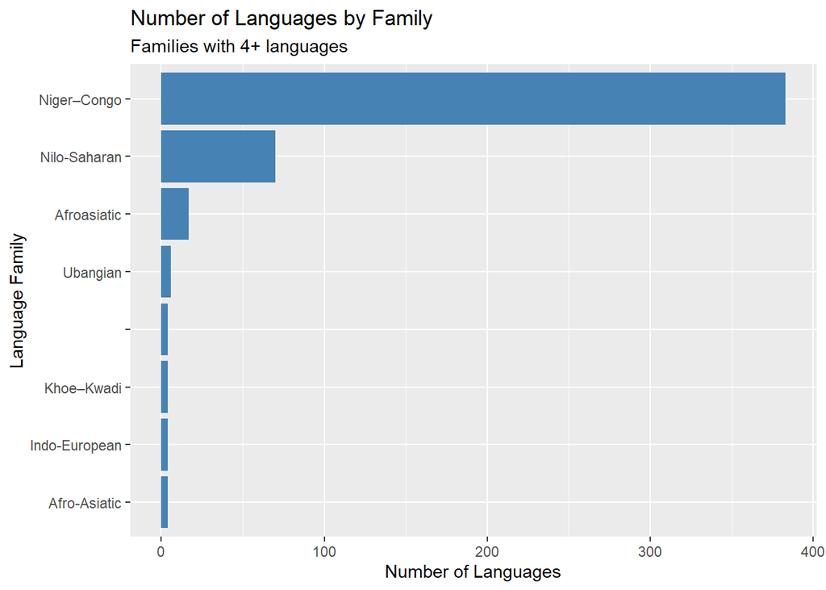

```r
# Language family summary
family_summary <- languages_summary |>
  group_by(family) |>
  summarize(
    n_languages = n(),
    total_speakers = sum(total_speakers)
  ) |>
  arrange(desc(n_languages))

# Visualize top families
top_families <- family_summary |>
  filter(n_languages >= 4)

ggplot(top_families, aes(x = reorder(family, n_languages), y = n_languages)) +
  geom_col(fill = "steelblue") +
  coord_flip() +
  labs(
    title = "Number of Languages by Family",
    subtitle = "Families with 4+ languages",
    x = "Language Family",
    y = "Number of Languages"
  )
```

**Key Finding:** The Niger–Congo family contains 383 languages (76% of all languages in the dataset), reflecting the incredible linguistic diversity of sub-Saharan Africa.

## Most Spoken Languages

While there are hundreds of languages, a small number account for the vast majority of speakers.

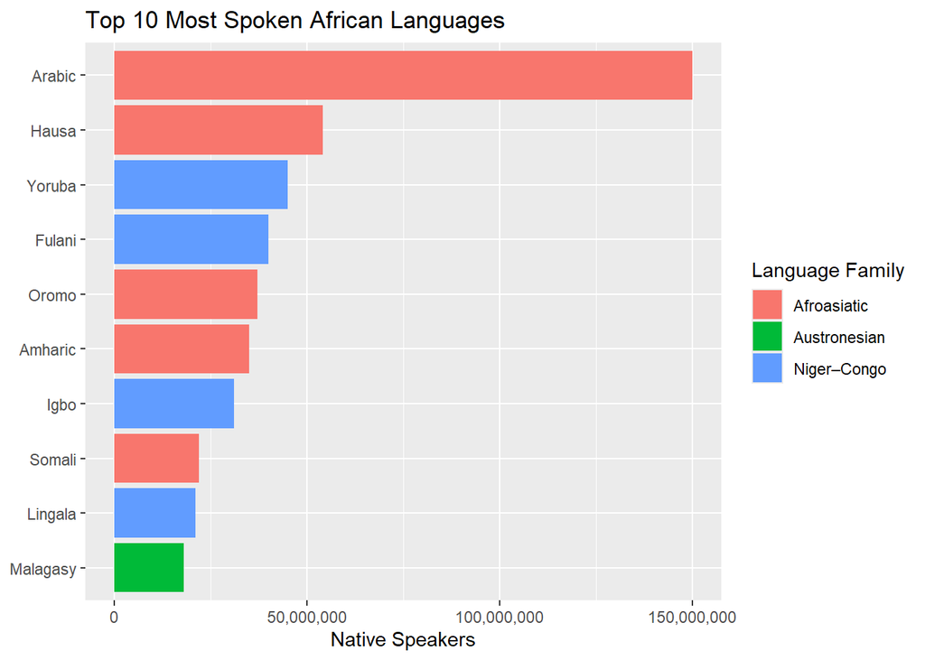

```r
# Top 10 most spoken languages
top_languages <- languages_summary |>
  slice_max(total_speakers, n = 10)

ggplot(top_languages, aes(x = reorder(language, total_speakers), y = total_speakers, fill = family)) +
  geom_col() +
  coord_flip() +
  scale_y_continuous(labels = scales::comma) +
  labs(
    title = "Top 10 Most Spoken African Languages",
    x = NULL,
    y = "Native Speakers",
    fill = "Language Family"
  )
```

## Geographic Distribution

Linguistic diversity varies dramatically by country, with some nations hosting dozens of languages.

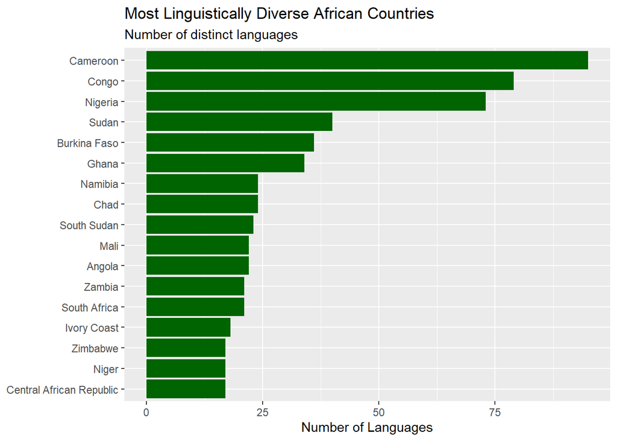

```r
# Country linguistic diversity
country_diversity <- africa |>
  group_by(country) |>
  summarize(
    n_languages = n_distinct(language),
    total_speakers = sum(native_speakers),
    n_families = n_distinct(family)
  ) |>
  arrange(desc(n_languages))

# Top 15 countries
top_countries <- country_diversity |>
  slice_max(n_languages, n = 15)

ggplot(top_countries, aes(x = reorder(country, n_languages), y = n_languages)) +
  geom_col(fill = "darkgreen") +
  coord_flip() +
  labs(
    title = "Most Linguistically Diverse African Countries",
    subtitle = "Number of distinct languages",
    x = NULL,
    y = "Number of Languages"
  )
```

## Cross-Border Languages

Many African languages transcend modern political boundaries, reflecting historical migration patterns and cultural connections.

```r
# Analyze cross-border languages
cross_border <- africa |>
  group_by(language) |>
  summarize(
    countries = n_distinct(country),
    speakers = max(native_speakers),
    country_list = paste(unique(country), collapse = ", ")
  ) |>
  filter(countries > 1) |>
  arrange(desc(countries))

# Top 10 most widespread
cross_border |>
  slice_max(countries, n = 10) |>
  select(language, countries, speakers) |>
  arrange(desc(countries))
```

```
## # A tibble: 11 × 3
##    language   countries  speakers
##    <chr>          <int>     <dbl>
##  1 Arabic            12 150000000
##  2 Fulani            10  40000000
##  3 Mooré              8  12000000
##  4 Soninke            8   2300000
##  5 Gourmanché         6   1500000
##  6 Lozi               6    725000
##  7 Bariba             5   1100000
##  8 Khwe               5      8000
##  9 Mampruli           5    230000
## 10 Portuguese         5  17000000
## 11 Swahili            5   5300000
```

**Key Finding:** Arabic is the most widespread language, spoken in 12 countries. Fulani spans 10 countries across West Africa, while Mooré and Soninke are each found in 8 nations.

## Endangered Languages

A significant portion of African languages have very small speaker populations, putting them at risk.

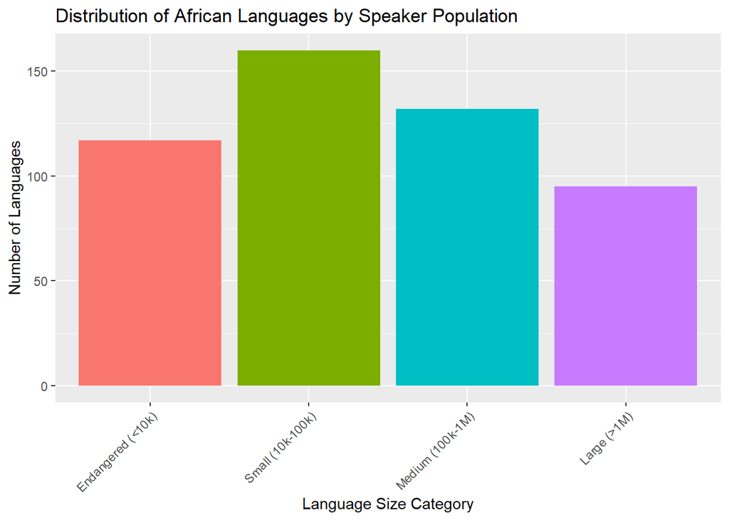

```r
# Distribution of language sizes
languages_summary |>
  mutate(size_category = case_when(
    total_speakers < 10000 ~ "Endangered (<10k)",
    total_speakers < 100000 ~ "Small (10k-100k)",
    total_speakers < 1000000 ~ "Medium (100k-1M)",
    TRUE ~ "Large (>1M)"
  )) |>
  count(size_category) |>
  mutate(size_category = factor(size_category,
                                 levels = c("Endangered (<10k)",
                                           "Small (10k-100k)",
                                           "Medium (100k-1M)",
                                           "Large (>1M)"))) |>
  ggplot(aes(x = size_category, y = n, fill = size_category)) +
  geom_col(show.legend = FALSE) +
  labs(
    title = "Distribution of African Languages by Speaker Population",
    x = "Language Size Category",
    y = "Number of Languages"
  ) +
  theme(axis.text.x = element_text(angle = 45, hjust = 1))
```

**Key Finding:** 117 languages (23%) have fewer than 10,000 speakers, making them potentially endangered. The majority of languages are small to medium-sized, with only a few “mega-languages.”

## Conclusion

Africa’s linguistic landscape reveals:

This rich linguistic heritage represents both a cultural treasure and a conservation challenge for the continent.